# Reef Water Column Productivity — RUN4 Respirometry Analysis

## Chamber Type Comparison

RUN3 and RUN4 include a mix of 350 mL BOD bottles and 500 mL mason jars, to check whether chamber design affects measured rates (e.g. via different bubble dynamics against the optode).

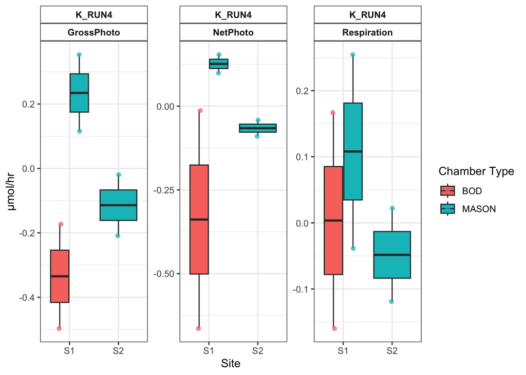

```r
RespoR_PR %>%
  filter(run_block %in% c("K_RUN3","K_RUN4")) %>%
  ggplot(aes(x = site_ID, y = Values, fill = chamber_type)) +
  geom_boxplot(outlier.shape = NA, position = position_dodge(width = 0.8)) +
  geom_point(aes(color = chamber_type),
             position = position_jitterdodge(jitter.width = 0.1, dodge.width = 0.8), alpha = 0.7) +
  facet_wrap(run_block ~ PR, scales = "free") +
  theme_bw() +
  labs(x = "Site", y = "µmol/hr", fill = "Chamber Type", color = "Chamber Type") +
  theme(strip.background = element_rect(fill = "white"), strip.text = element_text(face = "bold"))
```

```r
RespoR_PR %>%
  filter(run_block == "K_RUN4") %>%
  group_by(PR) %>%
  summarise(
    p_value = tryCatch(t.test(Values ~ chamber_type)$p.value, error = function(e) NA)
  ) %>%
  knitr::kable(digits = 3)
```

| PR | p_value |
| --- | --- |
| GrossPhoto | 0.179 |
| NetPhoto | 0.456 |
| Respiration | 0.902 |

## Temperature vs. O2 Diagnostic

Under LIGHT conditions, the water bath temperature shifts by about 1°C (vs. minimal drift in DARK) — partly driven by incubation light intensity, and partly by an ice pack added mid-run to counteract heating. This section checks whether LIGHT-period O2 increases reflect real productivity or are being driven by this temperature shift.

```r
acclim_sec <- 1800

RespoMeta_run4 <- RespoMeta %>%
  filter(run_block == "K_RUN4") %>%
  mutate(start_time = mdy_hms(paste(date, start_time)),
         stop_time  = mdy_hms(paste(date, stop_time)))

read_raw <- function(filename) {
  raw <- read_csv(skip = 1, file.path(path_run4, filename)) %>%
    dplyr::select(Date, Time, Value, Temp) %>%
    unite(Date, Time, col = "Time", sep = " ") %>%
    mutate(Time = mdy_hms(Time)) %>%
    drop_na(Time, Value, Temp) %>%
    arrange(Time)

  meta_rows <- RespoMeta_run4 %>% filter(FileID_csv == filename)

  meta_rows %>%
    pmap_dfr(function(light_dark, start_time, stop_time, ...) {
      raw %>%
        filter(Time >= start_time & Time <= stop_time) %>%
        mutate(t_sec = as.numeric(difftime(Time, first(Time), units = "secs"))) %>%
        filter(t_sec > acclim_sec) %>%
        mutate(light_dark = light_dark, sample_ID = sub("_O2.csv", "", filename))
    })
}

filenames_run4 <- list.files(path_run4, pattern = "csv$")
all_raw <- map_dfr(filenames_run4, read_raw)
light_only <- all_raw %>% filter(light_dark == "LIGHT")
```

### Correlation summary (LIGHT period)

```r
light_only %>%
  group_by(sample_ID) %>%
  summarise(cor_temp_o2 = cor(Temp, Value, use = "complete.obs")) %>%
  arrange(desc(abs(cor_temp_o2))) %>%
  knitr::kable(digits = 2)
```

| sample_ID | cor_temp_o2 |
| --- | --- |
| S2.2_RUN4 | -0.87 |
| S2.1_RUN4 | -0.63 |
| S1.2_RUN4 | 0.59 |
| S2.4_RUN4 | -0.52 |
| S1.1_RUN4 | -0.37 |
| S1.4_RUN4 | -0.35 |
| S1.3_RUN4 | 0.25 |

### Lag check (differenced, to control for shared trend)

Raw temp/O2 correlation and lag checks are inflated by the fact that both series are smoothly trending over the course of a LIGHT run — comparing consecutive *changes* instead of raw values removes this shared trend and isolates real moment-to-moment coupling.

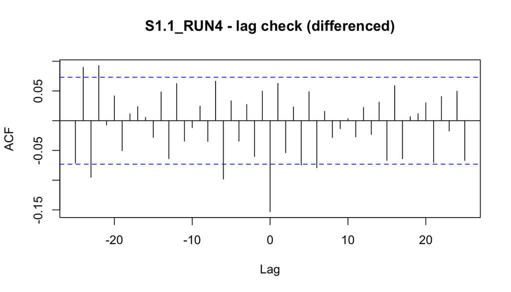

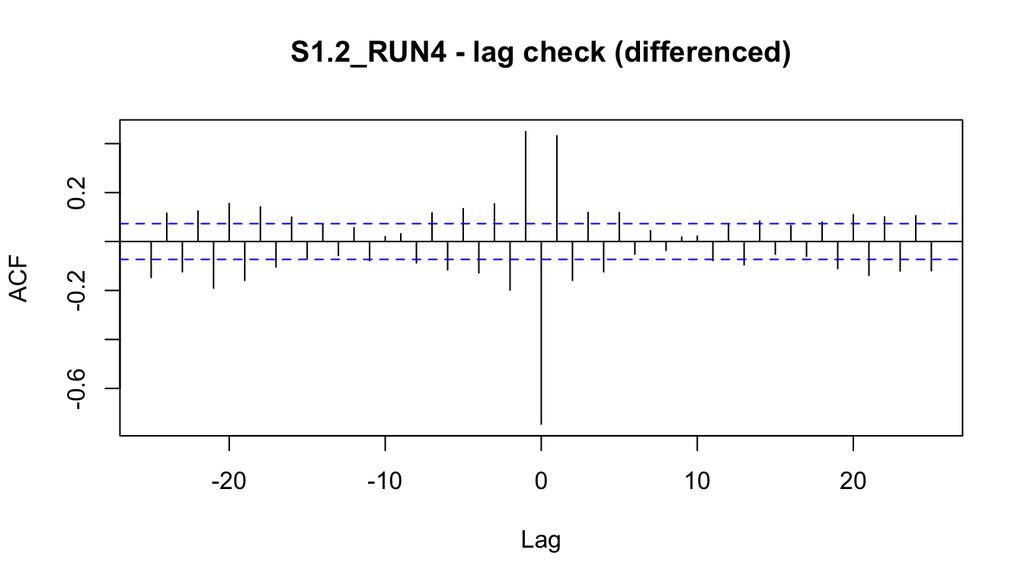

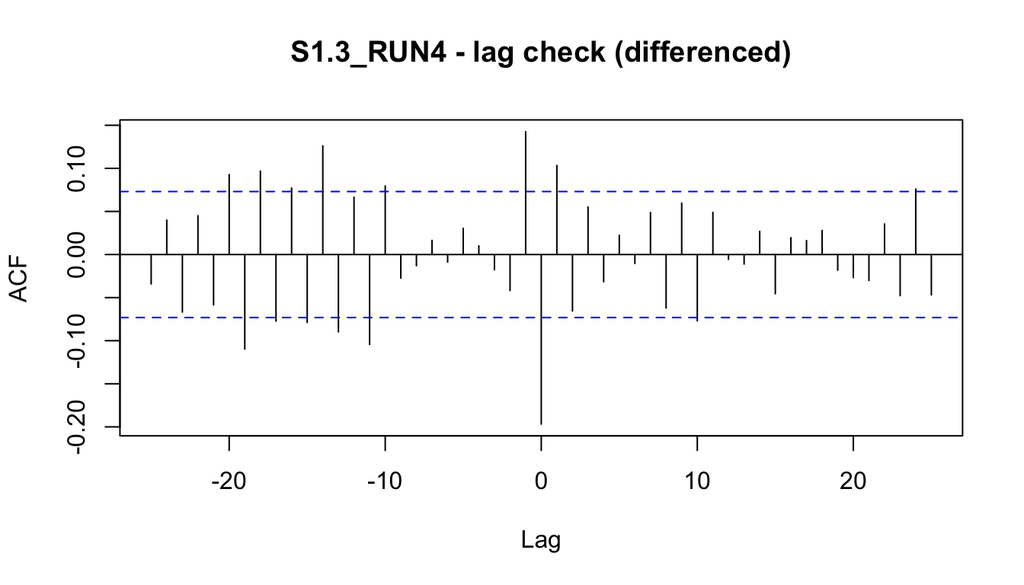

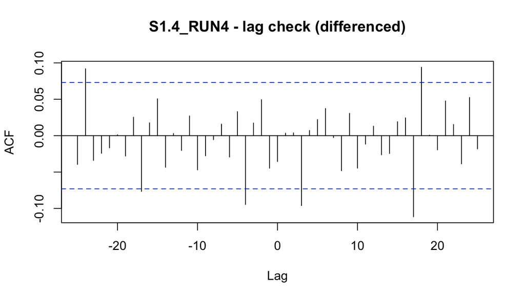

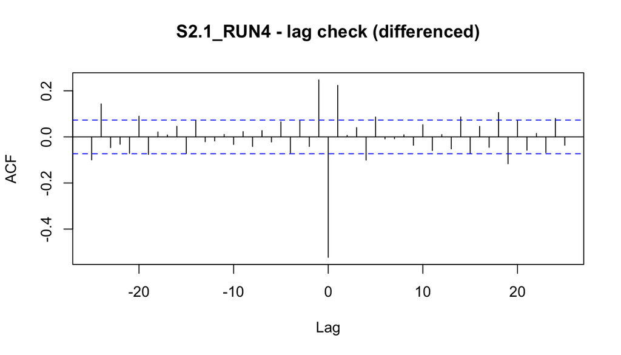

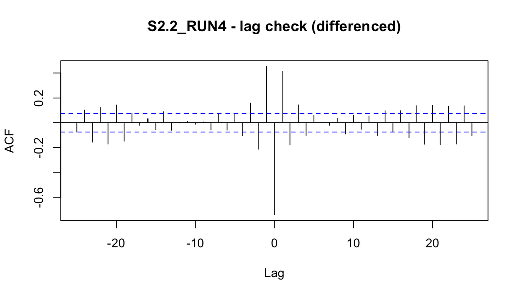

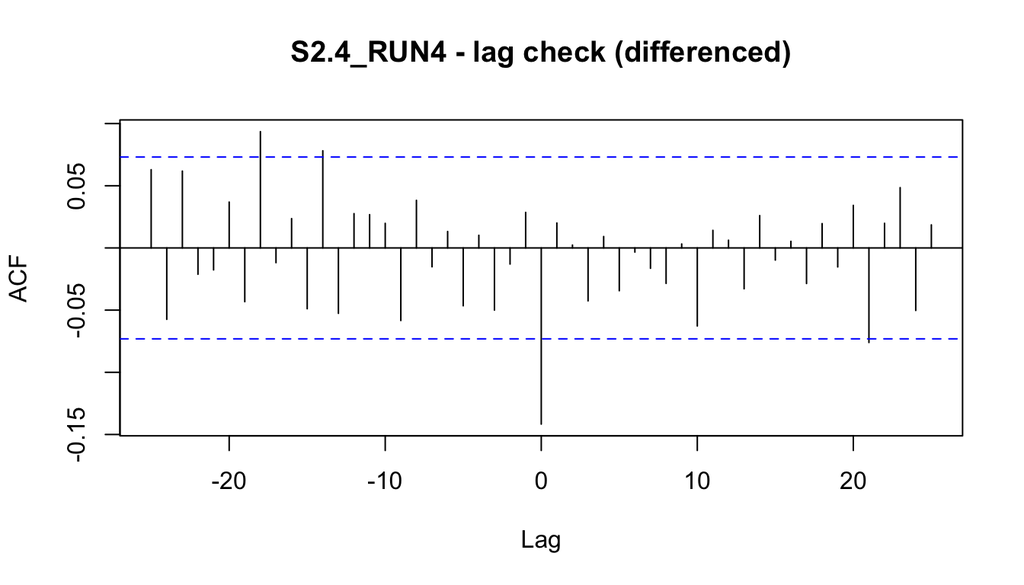

```r
for (id in unique(light_only$sample_ID)) {
  sub <- light_only %>% filter(sample_ID == id)
  if (nrow(sub) > 5) {
    ccf(diff(sub$Temp), diff(sub$Value), main = paste(id, "- lag check (differenced)"))
  }
}
```